# Vectorization and Monte Carlo Estimation

Statistics 506, Fall 2018

## Vectorization

Vectorization is a programming technique used to avoid explicit loops in order to improve the performance and, sometimes, readability of code.

In it’s simplest form, vectorization can refer to using built in vectorized functions. That is, rather than looping over a vector to compute its sum,

```r
x = -5e2:5e2

s0 = 0
for (i in 1:length(x)) {
  s0 = s0 + x[i]
}
```

we instead use the vectorized function `sum()`

```r
s1 = sum(x)
s0 == s1
```

```
## [1] TRUE
```

The latter is not only easier to type and read but is also faster.

```r
# Timing comparison for sums: -------------------------------------------------
library(tidyverse); library(microbenchmark)

# Functions to compare: -------------------------------------------------------
f0 = function(n){
  # Explicit looping
  x = 0:n

  s0 = 0
  for (i in 1:length(x)) {
    s0 = s0 + x[i]
  }

  s0
}

f1 = function(n){
  # Call sum
  x = 0:n
  s0 = sum(x)
  s0
}

microbenchmark( f0(1e4), f1(1e4), times = 1e3 ) %>%
  summary() %>%
  knitr::kable( digits = 1 )
```

| expr | min | lq | mean | median | uq | max | neval | cld |
| --- | --- | --- | --- | --- | --- | --- | --- | --- |
| f0(10000) | 380.0 | 382.4 | 467.4 | 384.7 | 402.6 | 57573.4 | 1000 | b |
| f1(10000) | 11.5 | 13.3 | 27.8 | 13.8 | 16.2 | 1730.5 | 1000 | a |

Why this is the case has to do with the fact that *R* is an *interpreted* language and not a *compiled* one. The difference in time you see here is primarily due to *R* needing to repeatedly *interpret* what your code means for each iteration of the loop.

Vectorization can be particularly useful in Monte Carlo studies where we might otherwise be inclined to use explicit loops. We will look at some examples after an introduction to Monte Carlo estimates.

### Reading

- [Vectorization in R: Why?](http://www.noamross.net/blog/2014/4/16/vectorization-in-r--why.html) by Noam Ross.
- [Advanced R](https://adv-r.hadley.nz/profiling.html#improve-perf) Sections 24.8 and 24.9
- [The R Inferno](http://www.burns-stat.com/pages/Tutor/R_inferno.pdf) by Patrick Burns. Please read chapters 2, 3 and 4.

## Monte Carlo Estimation

In statistics and data science we are often interested in computing expectations of random outcomes of various types. When analytically expectations are unavailable, it can be useful to obtain Monte Carlo approximations by simulating a random process and then directly averaging the values of interest.

This works because sample averages are generally good estimates of the corresponding expectation:

$${\bar{\theta}}_{n} := \sum_{i=1}^n X_i / n \to_p \theta := E[X].$$
$$\bar{\theta}_n \to_p \theta$$
In fact, assuming our data are independent and identically distributed (iid) from a distribution with finite variance, we can characterize the rate of convergence of a sample average to its population counterpart using the central limit theorem (CLT),

$$\sqrt{n}(\bar{\theta}_n - \theta') \to_{d} N(0,\sigma^2)$$
where $\sigma^2 = E[X^2] - E[X]^2$ is the variance of the underlying distribution. This can be useful for constructing approximate confidence intervals for the Monte Carlo error.

### Distribution functions

There are functions in **R** for simulating from many common distributions. Here are a few:

- `rnorm()` - Normal
- `runif()` - Uniform
- `rt()` - the t-distribution
- `rexp()` - Exponential
- `rpois()` - Poisson

Another useful function in R is `sample()` for sampling from a finite set of values, i.e. the discrete uniform distribution or any finite probability mass function.

### Random Seeds

When we call one of the `r*` functions to generate random draws from a distribution, **R** relies on a pseudo-random number generate to generate from $U(0,1)$ and produce the results. Thus the outcome of these calls depends on the current state of the generator. It is sometimes desirable to reproduce exactly the same pseudo-random sequence. You can do this by fixing the random seed using `set.seed()` which takes an integer argument. The function `RNGkind()` can be used to display or set the random number generator.

```r
RNGkind()
```

```
## [1] "Mersenne-Twister" "Inversion"
```

```r
a = runif(1)
b = runif(1)
a == b
```

```
## [1] FALSE
```

```r
set.seed(42)
a = runif(1)

set.seed(42)
b = runif(1)

a == b
```

```
## [1] TRUE
```

### Basic Example 1

As a quick example, let’s use these functions to compute percentiles for t-distributions with various degrees of freedom. Let $\theta_q$ be the parameter of interest,

$$\theta_q := F(q) = \int_{-\infty}^{q} f(x) dx = \int_{-\infty}^{\infty} 1[x \le q]f(x) dx$$
where $F(\cdot)$ is the CDF and $f(\cdot)$ the PDF of a given t-distribution.

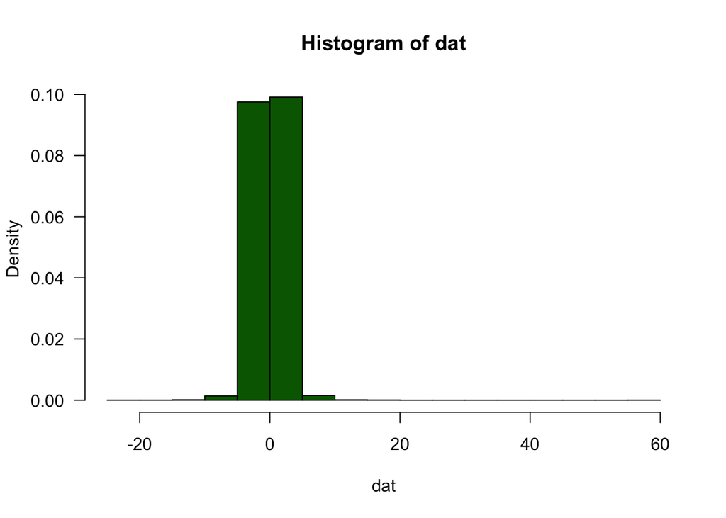

```r
## simulaton parameters
n  = 1e4
df = 3
quantiles = c(-1.96, 1.96)

## simulate data
dat = rt(n, df)
hist(dat, prob=TRUE, las=1, col='darkgreen')
```

```r
## Function(s) of interest
#theta_bar = c( mean(dat <= quantiles[1]), mean(dat <= quantiles[2]) )
theta_bar = vapply(quantiles, function(x) mean( dat<=x ), FUN.VALUE = 1.0 )
```

In this case, our Monte Carlo estimate of $(\theta_{-1.96}, \theta_{1.96})$ is $\bar{\theta}=$ (0.0704, 0.9269). The actual values are $(\theta_{-1.96}, \theta_{1.96})$ = (0.0724261, 0.9275739).

### Basic Example 2

Suppose we are interested in computing the following integral where $\phi$ is the standard normal density function:

$$\int_{-\infty}^\infty [\sin(x)-\cos(x)]^2\phi(x) dx.$$
We can recast this as the expectation below,

$$E[h(X)], \quad h(x) = [\sin(x)-\cos(x)]^2, \quad X \sim N(0,1).$$
The following **R** code provides a Monte Carlo estimate,

```r
n=1e4      # number of Monte Carlo samples
x=rnorm(n) # Monte Carlo sample
mean({sin(x) - cos(x)}^2) # estimate
```

```
## [1] 1.00058
```

Compare this to an estimate using numerical integration,

```r
integrand = function(x){
  {sin(x) - cos(x)}^2 * dnorm(x)
}
integrate(integrand, -Inf, Inf)
```

```
## 1 with absolute error < 9.4e-05
```

These values are fairly close to the analytic solution based on the identity $[\sin(x)-\cos(x)]^2 = 1 - \sin(2x)$ and the symmetry about zero of both $\sin(\cdot)$ and $\phi(\cdot)$. Suppose $X \sim N(0,1)$, then

$$\begin{align}
E[{\sin(X)-\cos(x)}^2]
&= E[1-\sin(2X)] \\
&=1 - E[\sin(2X)] \\
& = 1 - 0 \\
& = 1
\end{align}$$

The code below will produce a plot that illustrates why $E[\sin(a*X)] = 0$ for $X \sim N(0,1)$

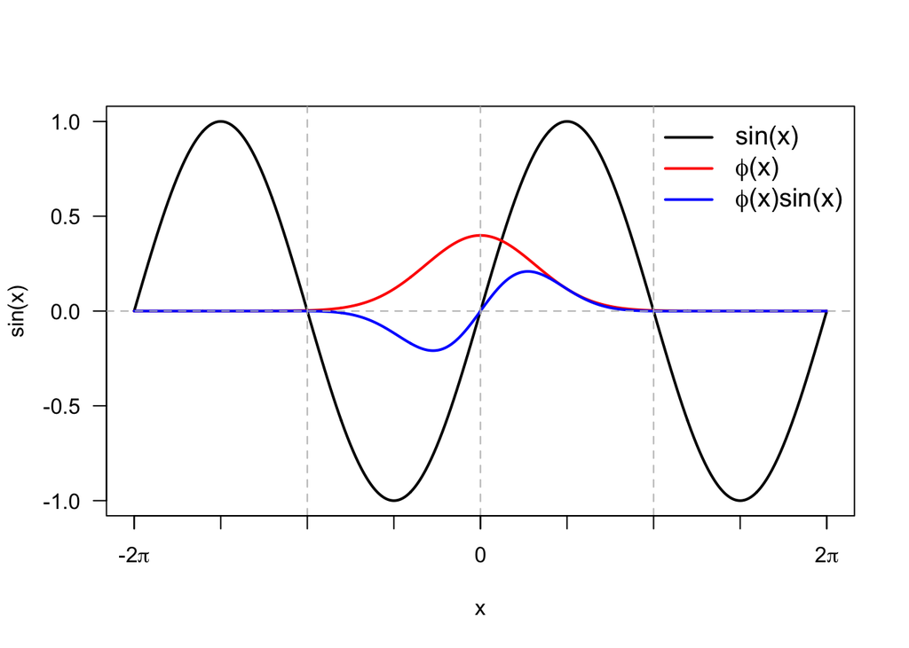

**Illustrating why E[sin(X)] = 0 for X ~ N(0,1).**

```r
cap="**Illustrating why E[sin(X)] = 0 for X ~ N(0,1).**"
curve(sin, -2*pi, 2*pi, n=1e3+1, lwd=2, las=1, xaxt='n')
curve(dnorm, -2*pi, 2*pi, n=1e3+1, lwd=2, col='red', add=TRUE)
curve(dnorm(x)*sin(x), -2*pi, 2*pi, n=1e3+1,
      lwd=2, col='blue', add=TRUE)
abline(h=0, v=c(-pi,0,pi), lty='dashed', col='grey')

legend('topright', col=c('black', 'red', 'blue'), lwd=2, bty='n', cex=1.2,
       legend=c('sin(x)', expression(phi*'(x)'), expression(phi*'(x)sin(x)'))
      )

axis(1, at=pi*seq(-2,2,2), labels=c(expression("-2"*pi), 0, expression("2"*pi)))
axis(1, at=pi*seq(-2,2,.5), labels=FALSE)
```

## Examples

The examples in this section are taken directly from Professor Shedden’s 2016 course notes which you can find [here](http://dept.stat.lsa.umich.edu/~kshedden/Courses/Stat506/r_vectorization/).

### Simulation Study for Nominal Confidence Intervals

As an example, we will investigate the coverage probability of nominal 95% confidence intervals when the data does not come from a Normal (Gaussian) distribution.

In the first example, we will assume the data come from an exponential distribution with mean one. The strategy here is to generate many (`mcrep`) data sets of size `n`. For each data vector, we then calculate a nominal 95% confidence interval for the mean and check whether this interval contains the true value one.

```r
mcrep = 10000                 # Simulation replications
n = 30                        # Sample size we are studying
xmat = rexp(n * mcrep)        # Simulate standard exponential data
dim(xmat) = c(mcrep, n)       # Each row is a dataset
mn = apply(xmat, 1, mean)     # Sample mean of each row
std = apply(xmat, 1, sd)      # Sample SD of each row
se = std / sqrt(n)            # Standard errors of the mean
m = qnorm(1 - {1 - .95} / 2)  # Multiplier for 95% confidence (~1.96)
lcb = mn - m*se               # lower confidence bounds
ucb = mn + m*se               # upper confidence bounds
target = 1                    # value we are estimating
cvrg_prob = mean( {lcb < target} & {ucb > target} ) # coverage probability
print(cvrg_prob)
```

```
## [1] 0.9198
```

Since coverage is binary with a fixed probability $p$, the number of intervals that cover one (“successes”) in our study is Binomial(`mcrep`, $p$). We can use this fact to estimate the Monte Carlo error which represents the uncertainty in our estimate from the chosen number of replications.

```r
mc_se = sqrt(cvrg_prob * {1 - cvrg_prob} / mcrep)
cvrg_prob_str = sprintf("%4.2f (%5.3f, %5.3f)",
                        cvrg_prob, cvrg_prob - m*mc_se, cvrg_prob + m*mc_se)
```

In this case the estimated coverage is 0.92 (0.914, 0.925).

### Broadcasting

We have previously discussed the need to be careful about **R** recycling values when performing arithmetic on arrays with differing dimensions. The formal name for this is *broadcasting* and it can be quite useful for vectorization.

Generally, when you perform a simple arithmetic operation “*” on arrays with the same dimensions the operation is applied point-wise so that `(A*B)[i,j] = A[i,j]*B[i,j]`. However, if the objects `A` and `B` have different dimensions, but flattened lengths with one a multiple of the other the values can be *broadcast* like this:

```r
xmat = c(1, 2, 3, 4, 5, 6)
dim(xmat) = c(3, 2)
xmat
```

```
##      [,1] [,2]
## [1,]    1    4
## [2,]    2    5
## [3,]    3    6
```

```r
xmat - c(1, 2, 3)
```

```
##      [,1] [,2]
## [1,]    0    3
## [2,]    0    3
## [3,]    0    3
```

Compare this to:

```r
ymat = c(1, 2, 3, 4, 5, 6) - c(1, 2, 3)
dim(ymat) = c(3, 2)
ymat
```

```
##      [,1] [,2]
## [1,]    0    3
## [2,]    0    3
## [3,]    0    3
```

In this case, if `X` has dimensions `m` and `n` and `v` length `k` we see that `(X-v)[i,j] = X[i,j] - v[{(j-1)*m+i mod k} + 1]`.

This is useful for centering each row of a matrix,

```r
xmat_c = xmat - rowMeans(xmat)
```

or computing row-wise variances,

```r
row_var1 = rowSums( {xmat - rowMeans(xmat)}^2 ) / {dim(xmat)[2] - 1}
```

We can compare this to direct computation using an implicit loop via the `apply` function:

```r
row_var2 = apply(xmat, 1, var)
all.equal(row_var1, row_var2)
```

```
## [1] TRUE
```

Let’s compare the timing of these two approaches:

```r
m = 100000
n = 30
xmat = rnorm(m*n)
dim(xmat) = c(m, n)

tm1 = proc.time()
rowvar1 = apply(xmat, 1, var)
tm1 = proc.time() - tm1

tm2 = proc.time()
rowvar2 = rowMeans((xmat - rowMeans(xmat))^2) * dim(xmat)[2] / (dim(xmat)[2] - 1)
tm2 = proc.time() - tm2

cat("Apply: ", tm1[3], "s, Vectorized: ", tm2[3], "s, Ratio: ",
    round( tm1[3] / tm2[3], 1), '.\n', sep = '' )
```

```
## Apply: 1.871s, Vectorized: 0.038s, Ratio: 49.2.
```

### Correlation Coefficients

In the next example, we consider the problem of computing the correlation coefficient between many vectors $x$ and a single outcome $y$. This can be useful when screening a large set of potential predictors for a relationship with an outcome of interest $y$.

First, we generate data that has `n` observations, `m` predictors, and expected correlation `r` between each predictor and $y$.

```r
n = 30
m = 10000
r = 0.4
yvec = rnorm(n)
xmat = outer(array(1, m), yvec)
xmat = 0.4*xmat + sqrt(1 - 0.4^2)*rnorm(n * m)
```

Now, we can compute the correlations between each row of `xmat` and `y` and compare approaches.

```r
# First approach, calculate as a loop
tm1 = proc.time()
r1 = NULL
for (i in 1:m) {
    r1[i] = cor(xmat[i, ], yvec)
}
tm1 = proc.time() - tm1

# Second approach, functional style with apply
tm2 = proc.time()
r2 = apply(xmat, 1, function(v) cor(v, yvec) )
tm2 = proc.time() - tm2
all.equal(r1, r2)
```

```
## [1] TRUE
```

```r
# Third approach, use linear algebra
tm3 = proc.time()
rmn = rowMeans(xmat)
xmat_c = xmat - outer(rmn, array(1, n))
rsd = apply(xmat, 1, sd)
xmat_s = xmat_c / outer(rsd, array(1, n))
yvec_s = {yvec - mean(yvec)} / sd(yvec)
r3 = xmat_s %*% yvec_s / {n - 1}
r3 = as.vector(r3)
tm3 = proc.time() - tm3
all.equal(r1, r3)
```

```
## [1] TRUE
```

```r
# Fourth approach, use linear algebra with broadcasting
tm4 = proc.time()
rmn = rowMeans(xmat)
xmat_c = xmat - rmn
rvar = rowSums(xmat_c^2) / {dim(xmat)[2] - 1}
rsd = sqrt(rvar)
xmat_s = xmat_c / rsd
yvec_s = {yvec - mean(yvec)} / sd(yvec)
r4 = xmat_s %*% yvec_s / {n - 1}
r4 = as.vector(r4)
tm4 = proc.time() - tm4
all.equal(r1, r4)
```

```
## [1] TRUE
```

```r
# Fifth and final approach, use cor and discard pairs without y
# Note: The version presented in class contained an error.
tm5 = proc.time()
y_xmat = cbind(yvec, t(xmat))
r5 = cor(y_xmat)[-1,1]
attr(r5, 'names') = NULL
tm5 = proc.time() - tm5
all.equal(r1, r5)
```

```
## [1] TRUE
```

```r
# Format and print the results
cat(sprintf("1: %5.3f s \n2: %5.3f s \n3: %5.3f s \n4: %5.3f s \n5: %5.3f s \n",
            tm1[3], tm2[3], tm3[3], tm4[3], tm5[3]
            )
    )
```

```
## 1: 0.287 s
## 2: 0.290 s
## 3: 0.372 s
## 4: 0.014 s
## 5: 4.789 s
```

The fourth approach using linear algebra and broadcasting is by far the most efficient here. All approaches are much more efficient than computing `choose(10001, 2)` correlations when we only need 10,000.

While we should keep in mind that this was a single trial and not a formal comparison with replicates, a difference of this size is still meaningful. We should also be aware that one of the reasons the other approaches are slower is the time needed to allocate memory for (larger) intermediate objects.

#### Garbage Collection

The time needed to allocate memory can be influenced by something called *garbage collection* 🗑 ♻️. In languages like **R** that bind names to values, garbage collection refers to freeing up memory that is no longer needed because there are no longer any names pointing to it.

Garbage collection is triggered automatically when **R** needs more memory. As this could happen in the middle of something you are timing, you may get more consistent results if you explicitly force garbage collection prior to starting the timer. However, you rarely need to consider this elsewhere and not everyone agrees it is a best practice.

```r
gc()
```

```
##           used (Mb) gc trigger  (Mb)  max used  (Mb)
## Ncells 1836244 98.1    3205452 171.2   3205452 171.2
## Vcells 4632105 35.4  100614205 767.7 105233356 802.9
```

```r
# First approach, calculate as a loop
tm1 = proc.time()
r1 = NULL
for (i in 1:m) {
    r1[i] = cor(xmat[i, ], yvec)
}
tm1 = proc.time() - tm1

gc()
```

```
##           used (Mb) gc trigger  (Mb)  max used  (Mb)
## Ncells 1836170 98.1    3205452 171.2   3205452 171.2
## Vcells 4631956 35.4   80491364 614.2 105233356 802.9
```

```r
# Second approach, functional style with apply
tm2 = proc.time()
r2 = apply(xmat, 1, function(v) cor(v, yvec))
tm2 = proc.time() - tm2

gc()
```

```
##           used (Mb) gc trigger  (Mb)  max used  (Mb)
## Ncells 1836235 98.1    3205452 171.2   3205452 171.2
## Vcells 4632074 35.4   64393091 491.3 105233356 802.9
```

```r
# Third approach, use linear algebra
tm3 = proc.time()
rmn = rowMeans(xmat)
xmat_c = xmat - outer(rmn, array(1, n))
rsd = apply(xmat, 1, sd)
xmat_s = xmat_c / outer(rsd, array(1, n))
yvec_s = {yvec - mean(yvec)} / sd(yvec)
r3 = xmat_s %*% yvec_s / {n - 1}
r3 = as.vector(r3)
tm3 = proc.time() - tm3

gc()
```

```
##           used (Mb) gc trigger  (Mb)  max used  (Mb)
## Ncells 1836321 98.1    3205452 171.2   3205452 171.2
## Vcells 4632164 35.4   51514472 393.1 105233356 802.9
```

```r
# Fourth approach, use linear algebra with broadcasting
tm4 = proc.time()
rmn = rowMeans(xmat)
xmat_c = xmat - rmn
rvar = rowSums(xmat_c^2) / {dim(xmat)[2] - 1}
rsd = sqrt(rvar)
xmat_s = xmat_c / rsd
yvec_s = {yvec - mean(yvec)} / sd(yvec)
r4 = xmat_s %*% yvec_s / {n - 1}
r4 = as.vector(r4)
tm4 = proc.time() - tm4

# Format and print the results
cat(sprintf("1: %5.3f s \n2: %5.3f s \n3: %5.3f s \n4: %5.3f s \n",
            tm1[3],tm2[3],tm3[3],tm4[3]
            )
    )
```

```
## 1: 0.274 s
## 2: 0.279 s
## 3: 0.185 s
## 4: 0.015 s
```

### Exercises

1. Suggest a way to further speed up the broadcasting approach. Test it.
2. Repeat the exercise above with observations in rows and predictors in columns, i.e. when `x` has dimension `n` by `m` rather than `m` by `n`.

## Functional programming in Monte Carlo Studies

Recall our original example of computing coverage probabilities of nominal confidence intervals for non-Gaussian data.

If we wanted to carry out similar studies for many distributions, we may wish to write a function whose body carries out the simulation study using configurable parameters.

Here is the original example with a few changes.

```r
mcrep = 10000                # Simulation replications
n = 30                       # Sample size we are studying
target = 1                   # value we are estimating
conf_level = .95             # Confidence level

xmat = rexp(n * mcrep)       # Simulate standard exponential data
dim(xmat) = c(mcrep, n)      # Each row is a dataset
mn = apply(xmat, 1, mean)    # Sample mean of each row
std = apply(xmat, 1, sd)     # Sample SD of each row
se = std / sqrt(n)           # Standard errors of the mean
m = qnorm(1 - {1 - conf_level} / 2)       # Multiplier for confidence level
lcb = mn - m*se              # lower confidence bounds
ucb = mn + m*se              # upper confidence bounds

cvrg_prob = mean( {lcb < target} & {ucb > target}) # coverage probability
```

Below we incorporate the simulation into a function with parameters for simulation settings. Here we use the special argument `...` to pass additional parameters to `rgen` by name.

```r
## Function to estimate nominal coverage probabilities
estimate_nominal_coverage =
  function(rgen, target, mcrep=1e4, n=30, conf_level=.95, ...){
  # rgen       - a function generating a vector of simulated data, i.e rexp(),
  #              with length equal to its first argument.
  # target     - the actual expectation of rgen()
  # mcrep, n   - the number of Monte Carlo replications and sample size, respectively.
  # conf_level - the nominal coverage probability
  # ...        - additional parameters to pass to rgen

  xmat = rgen(n * mcrep, ...)  # Simulate data
  dim(xmat) = c(mcrep, n)      # Each row is a dataset
  mn = apply(xmat, 1, mean)    # Sample mean of each row
  std = apply(xmat, 1, sd)     # Sample SD of each row
  se = std / sqrt(n)           # Standard errors of the mean
  m = qnorm(1 - {1 - conf_level}/2)       # Multiplier for confidence level
  lcb = mn - m*se              # lower confidence bounds
  ucb = mn + m*se              # upper confidence bounds

  mean((lcb < target) & (ucb > target)) # coverage probability
}
```

Now we can use `estimate_nominal_coverage` for multiple simulations.

```r
# Geometric(p) with mean (1-p)/p
estimate_nominal_coverage(rgeom, target=3, p = .25)
```

```
## [1] 0.9223
```

```r
# Poisson(lambda) with mean lambda
estimate_nominal_coverage(rpois, target=4, lambda = 4)
```

```
## [1] 0.9357
```

```r
# t(df) with mean 0
estimate_nominal_coverage(rt, target=0, df=2)
```

```
## [1] 0.9496
```

This could be useful, say, for exploring how the mean impacts the coverage probability for a particular distribution.

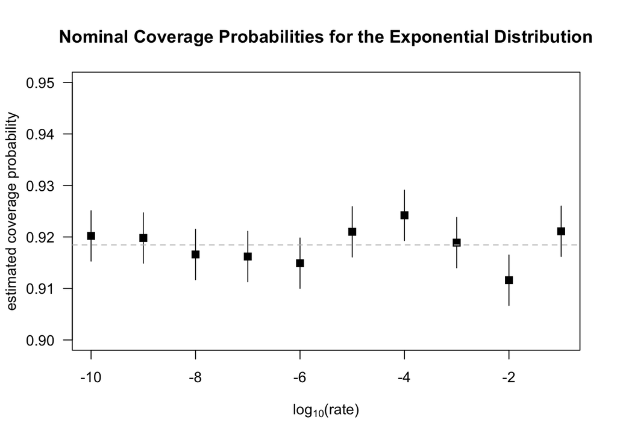

```r
lambdas = exp(-seq(1,10,1))  # rate parameters to explore
coverage_probs = c()         # store the results
for (i in 1:length(lambdas)) {
  rate = lambdas[i]
  coverage_probs[i] = estimate_nominal_coverage(rexp, target=1/rate, rate=rate)
}

plot(-seq(1,10,1), coverage_probs, ylab='estimated coverage probability',
     xlab=expression('log'[10]*'(rate)'), las=1, pch=15, cex=1.2, ylim=c(.9,.95),
     main='Nominal Coverage Probabilities for the Exponential Distribution')

# Add Monte Carlo confidence bounds
for (i in 1:length(lambdas)) {
  x = rep(-seq(1,10,1)[i], 2)
  y = coverage_probs[i] + qnorm(.975)*c(-1,1)*.25/sqrt(1e4)
  lines(x,y)
}

# add a reference line for the global mean
abline(h=mean(coverage_probs), lty='dashed', col='grey')
```

### Exercise

1. Use the function `estimate_nominal_coverage()` defined above to explore how the nominal coverage changes with the sample size `n` for various distributions.